# Risk Factor Analysis

## Outcome Variable

**Outcome Variable:** wasted

## Predictor Variables

**Intervention Variable:** impsan

**Adjustment Set:**

- arm
- sex
- W_mage
- meducyrs
- feducyrs
- hhwealth_quart
- hfoodsec
- W_mhtcm
- W_nrooms
- W_nchldlt5
- W_parity
- impfloor
- safeh20
- delta_W_mage
- delta_meducyrs
- delta_feducyrs
- delta_hhwealth_quart
- delta_hfoodsec
- delta_W_mhtcm
- delta_W_nrooms
- delta_W_nchldlt5
- delta_W_parity
- delta_impfloor
- delta_safeh20

## Stratifying Variables

The analysis was stratified on these variable(s):

- agecat
- studyid
- country

## Data Summary

| agecat | studyid | country | impsan | wasted | n_cell | n |
| --- | --- | --- | --- | --- | --- | --- |
| Birth | ki0047075b-MAL-ED | BANGLADESH | 0 | 0 | 32 | 222 |
| Birth | ki0047075b-MAL-ED | BANGLADESH | 0 | 1 | 4 | 222 |
| Birth | ki0047075b-MAL-ED | BANGLADESH | 1 | 0 | 152 | 222 |
| Birth | ki0047075b-MAL-ED | BANGLADESH | 1 | 1 | 34 | 222 |
| Birth | ki0047075b-MAL-ED | BRAZIL | 0 | 0 | 3 | 167 |
| Birth | ki0047075b-MAL-ED | BRAZIL | 0 | 1 | 1 | 167 |
| Birth | ki0047075b-MAL-ED | BRAZIL | 1 | 0 | 158 | 167 |
| Birth | ki0047075b-MAL-ED | BRAZIL | 1 | 1 | 5 | 167 |
| Birth | ki0047075b-MAL-ED | INDIA | 0 | 0 | 86 | 188 |
| Birth | ki0047075b-MAL-ED | INDIA | 0 | 1 | 12 | 188 |
| Birth | ki0047075b-MAL-ED | INDIA | 1 | 0 | 72 | 188 |
| Birth | ki0047075b-MAL-ED | INDIA | 1 | 1 | 18 | 188 |
| Birth | ki0047075b-MAL-ED | NEPAL | 0 | 0 | 1 | 166 |
| Birth | ki0047075b-MAL-ED | NEPAL | 0 | 1 | 0 | 166 |
| Birth | ki0047075b-MAL-ED | NEPAL | 1 | 0 | 145 | 166 |
| Birth | ki0047075b-MAL-ED | NEPAL | 1 | 1 | 20 | 166 |
| Birth | ki0047075b-MAL-ED | PERU | 0 | 0 | 179 | 243 |
| Birth | ki0047075b-MAL-ED | PERU | 0 | 1 | 4 | 243 |
| Birth | ki0047075b-MAL-ED | PERU | 1 | 0 | 60 | 243 |
| Birth | ki0047075b-MAL-ED | PERU | 1 | 1 | 0 | 243 |
| Birth | ki0047075b-MAL-ED | SOUTH AFRICA | 0 | 0 | 196 | 211 |
| Birth | ki0047075b-MAL-ED | SOUTH AFRICA | 0 | 1 | 13 | 211 |
| Birth | ki0047075b-MAL-ED | SOUTH AFRICA | 1 | 0 | 2 | 211 |
| Birth | ki0047075b-MAL-ED | SOUTH AFRICA | 1 | 1 | 0 | 211 |
| Birth | ki0047075b-MAL-ED | TANZANIA, UNITED REPUBLIC OF | 0 | 0 | 107 | 109 |
| Birth | ki0047075b-MAL-ED | TANZANIA, UNITED REPUBLIC OF | 0 | 1 | 2 | 109 |
| Birth | ki0047075b-MAL-ED | TANZANIA, UNITED REPUBLIC OF | 1 | 0 | 0 | 109 |
| Birth | ki0047075b-MAL-ED | TANZANIA, UNITED REPUBLIC OF | 1 | 1 | 0 | 109 |
| Birth | ki1017093-NIH-Birth | BANGLADESH | 0 | 0 | 15 | 28 |
| Birth | ki1017093-NIH-Birth | BANGLADESH | 0 | 1 | 4 | 28 |

[output cut: 166 more lines]

The following strata were considered:

- agecat: 24 months, studyid: ki0047075b-MAL-ED, country: BANGLADESH
- agecat: 24 months, studyid: ki0047075b-MAL-ED, country: BRAZIL
- agecat: 24 months, studyid: ki0047075b-MAL-ED, country: INDIA
- agecat: 24 months, studyid: ki0047075b-MAL-ED, country: NEPAL
- agecat: 24 months, studyid: ki0047075b-MAL-ED, country: PERU
- agecat: 24 months, studyid: ki0047075b-MAL-ED, country: SOUTH AFRICA
- agecat: 24 months, studyid: ki0047075b-MAL-ED, country: TANZANIA, UNITED REPUBLIC OF
- agecat: 24 months, studyid: ki1017093-NIH-Birth, country: BANGLADESH
- agecat: 24 months, studyid: ki1017093b-PROVIDE, country: BANGLADESH
- agecat: 24 months, studyid: ki1017093c-NIH-Crypto, country: BANGLADESH
- agecat: 24 months, studyid: ki1114097-CONTENT, country: PERU
- agecat: 24 months, studyid: ki1135781-COHORTS, country: GUATEMALA
- agecat: 24 months, studyid: ki1135781-COHORTS, country: INDIA
- agecat: 24 months, studyid: ki1135781-COHORTS, country: PHILIPPINES
- agecat: 24 months, studyid: ki1148112-LCNI-5, country: MALAWI
- agecat: 24 months, studyid: kiGH5241-JiVitA-3, country: BANGLADESH
- agecat: 24 months, studyid: kiGH5241-JiVitA-4, country: BANGLADESH
- agecat: 6 months, studyid: ki0047075b-MAL-ED, country: BANGLADESH
- agecat: 6 months, studyid: ki0047075b-MAL-ED, country: BRAZIL
- agecat: 6 months, studyid: ki0047075b-MAL-ED, country: INDIA
- agecat: 6 months, studyid: ki0047075b-MAL-ED, country: NEPAL
- agecat: 6 months, studyid: ki0047075b-MAL-ED, country: PERU
- agecat: 6 months, studyid: ki0047075b-MAL-ED, country: SOUTH AFRICA
- agecat: 6 months, studyid: ki0047075b-MAL-ED, country: TANZANIA, UNITED REPUBLIC OF
- agecat: 6 months, studyid: ki1017093-NIH-Birth, country: BANGLADESH
- agecat: 6 months, studyid: ki1017093b-PROVIDE, country: BANGLADESH
- agecat: 6 months, studyid: ki1017093c-NIH-Crypto, country: BANGLADESH
- agecat: 6 months, studyid: ki1114097-CONTENT, country: PERU
- agecat: 6 months, studyid: ki1135781-COHORTS, country: GUATEMALA
- agecat: 6 months, studyid: ki1135781-COHORTS, country: INDIA
- agecat: 6 months, studyid: ki1135781-COHORTS, country: PHILIPPINES
- agecat: 6 months, studyid: ki1148112-LCNI-5, country: MALAWI
- agecat: 6 months, studyid: kiGH5241-JiVitA-3, country: BANGLADESH
- agecat: 6 months, studyid: kiGH5241-JiVitA-4, country: BANGLADESH
- agecat: Birth, studyid: ki0047075b-MAL-ED, country: BANGLADESH
- agecat: Birth, studyid: ki0047075b-MAL-ED, country: BRAZIL
- agecat: Birth, studyid: ki0047075b-MAL-ED, country: INDIA
- agecat: Birth, studyid: ki0047075b-MAL-ED, country: NEPAL
- agecat: Birth, studyid: ki0047075b-MAL-ED, country: PERU
- agecat: Birth, studyid: ki0047075b-MAL-ED, country: SOUTH AFRICA
- agecat: Birth, studyid: ki0047075b-MAL-ED, country: TANZANIA, UNITED REPUBLIC OF
- agecat: Birth, studyid: ki1017093-NIH-Birth, country: BANGLADESH
- agecat: Birth, studyid: ki1017093c-NIH-Crypto, country: BANGLADESH
- agecat: Birth, studyid: ki1114097-CONTENT, country: PERU
- agecat: Birth, studyid: ki1135781-COHORTS, country: GUATEMALA
- agecat: Birth, studyid: ki1135781-COHORTS, country: INDIA
- agecat: Birth, studyid: ki1135781-COHORTS, country: PHILIPPINES
- agecat: Birth, studyid: kiGH5241-JiVitA-3, country: BANGLADESH
- agecat: Birth, studyid: kiGH5241-JiVitA-4, country: BANGLADESH

### Dropped Strata

Some strata were dropped due to rare outcomes:

- agecat: Birth, studyid: ki0047075b-MAL-ED, country: BANGLADESH
- agecat: Birth, studyid: ki0047075b-MAL-ED, country: BRAZIL
- agecat: Birth, studyid: ki0047075b-MAL-ED, country: NEPAL
- agecat: Birth, studyid: ki0047075b-MAL-ED, country: PERU
- agecat: Birth, studyid: ki0047075b-MAL-ED, country: SOUTH AFRICA
- agecat: Birth, studyid: ki0047075b-MAL-ED, country: TANZANIA, UNITED REPUBLIC OF
- agecat: Birth, studyid: ki1017093-NIH-Birth, country: BANGLADESH
- agecat: Birth, studyid: ki1017093c-NIH-Crypto, country: BANGLADESH
- agecat: Birth, studyid: ki1114097-CONTENT, country: PERU
- agecat: 6 months, studyid: ki0047075b-MAL-ED, country: BANGLADESH
- agecat: 6 months, studyid: ki0047075b-MAL-ED, country: BRAZIL
- agecat: 6 months, studyid: ki0047075b-MAL-ED, country: NEPAL
- agecat: 6 months, studyid: ki0047075b-MAL-ED, country: PERU
- agecat: 6 months, studyid: ki0047075b-MAL-ED, country: SOUTH AFRICA
- agecat: 6 months, studyid: ki0047075b-MAL-ED, country: TANZANIA, UNITED REPUBLIC OF
- agecat: 6 months, studyid: ki1017093b-PROVIDE, country: BANGLADESH
- agecat: 6 months, studyid: ki1114097-CONTENT, country: PERU
- agecat: 6 months, studyid: ki1135781-COHORTS, country: GUATEMALA
- agecat: 6 months, studyid: ki1135781-COHORTS, country: PHILIPPINES
- agecat: 6 months, studyid: ki1148112-LCNI-5, country: MALAWI
- agecat: 24 months, studyid: ki0047075b-MAL-ED, country: BRAZIL
- agecat: 24 months, studyid: ki0047075b-MAL-ED, country: NEPAL
- agecat: 24 months, studyid: ki0047075b-MAL-ED, country: PERU
- agecat: 24 months, studyid: ki0047075b-MAL-ED, country: SOUTH AFRICA
- agecat: 24 months, studyid: ki0047075b-MAL-ED, country: TANZANIA, UNITED REPUBLIC OF
- agecat: 24 months, studyid: ki1017093b-PROVIDE, country: BANGLADESH
- agecat: 24 months, studyid: ki1017093c-NIH-Crypto, country: BANGLADESH
- agecat: 24 months, studyid: ki1114097-CONTENT, country: PERU
- agecat: 24 months, studyid: ki1135781-COHORTS, country: GUATEMALA
- agecat: 24 months, studyid: ki1148112-LCNI-5, country: MALAWI

## Methods Detail

We’re interested in the causal parameters $E[Y_a]$ for all values of $a \in \mathcal{A}$. These parameters represent the mean outcome if, possibly contrary to fact, we intervened to set all units to have $A=a$. Under the randomization and positivity assumptions, these are identified by the statistical parameters $\psi_a=E_W[E_{Y|A,W}(Y|A=a,W)]$. In addition, we’re interested in the mean of $Y$, $E[Y]$ under no intervention (the observed mean). We will estimate these parameters by using SuperLearner to fit the relevant likelihood factors – $E_{Y|A,W}(Y|A=a,W)$ and $p(A=a|W)$, and then updating our likelihood fit using a joint TMLE.

For unadjusted analyses ($W=\{\}$), initial likelihoods were estimated using Lrnr_glm to estimate the simple $E(Y|A)$ and Lrnr_mean to estimate $p(A)$. For adjusted analyses, a small library containing Lrnr_glmnet, Lrnr_xgboost, and Lrnr_mean was used.

Having estimated these parameters, we will then use the delta method to estimate relative risks and attributable risks relative to a prespecified baseline level of $A$.

# Results Detail

## Results Plots

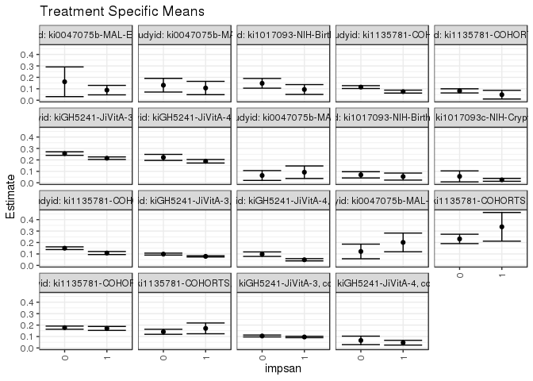

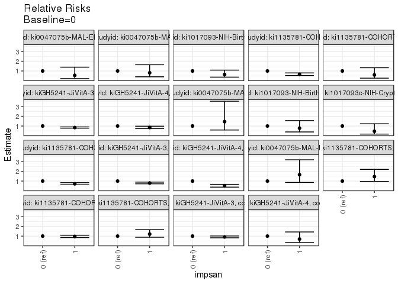

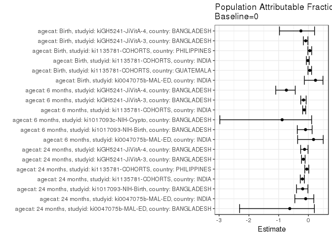

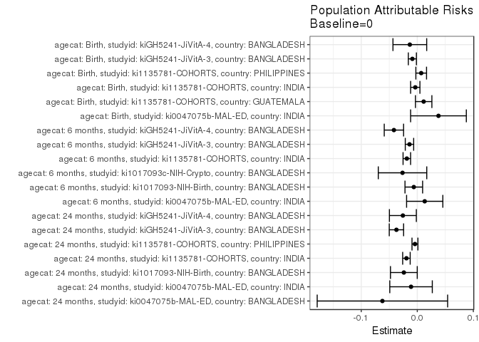

## Results Table

### Parameter: TSM

| agecat | studyid | country | intervention_level | baseline_level | estimate | ci_lower | ci_upper |
| --- | --- | --- | --- | --- | --- | --- | --- |
| Birth | ki0047075b-MAL-ED | INDIA | 0 | NA | 0.1217696 | 0.0579136 | 0.1856256 |
| Birth | ki0047075b-MAL-ED | INDIA | 1 | NA | 0.2008318 | 0.1193063 | 0.2823573 |
| Birth | ki1135781-COHORTS | GUATEMALA | 0 | NA | 0.2313875 | 0.1903851 | 0.2723899 |
| Birth | ki1135781-COHORTS | GUATEMALA | 1 | NA | 0.3371035 | 0.2116234 | 0.4625836 |
| Birth | ki1135781-COHORTS | INDIA | 0 | NA | 0.1775457 | 0.1639441 | 0.1911474 |
| Birth | ki1135781-COHORTS | INDIA | 1 | NA | 0.1708467 | 0.1536324 | 0.1880610 |
| Birth | ki1135781-COHORTS | PHILIPPINES | 0 | NA | 0.1413281 | 0.1193396 | 0.1633165 |
| Birth | ki1135781-COHORTS | PHILIPPINES | 1 | NA | 0.1711540 | 0.1240002 | 0.2183078 |
| Birth | kiGH5241-JiVitA-3 | BANGLADESH | 0 | NA | 0.1047068 | 0.0962859 | 0.1131276 |
| Birth | kiGH5241-JiVitA-3 | BANGLADESH | 1 | NA | 0.0960472 | 0.0898586 | 0.1022358 |
| Birth | kiGH5241-JiVitA-4 | BANGLADESH | 0 | NA | 0.0660147 | 0.0289097 | 0.1031196 |
| Birth | kiGH5241-JiVitA-4 | BANGLADESH | 1 | NA | 0.0458700 | 0.0249823 | 0.0667576 |
| 6 months | ki0047075b-MAL-ED | INDIA | 0 | NA | 0.0640000 | 0.0210013 | 0.1069987 |
| 6 months | ki0047075b-MAL-ED | INDIA | 1 | NA | 0.0925926 | 0.0378079 | 0.1473773 |
| 6 months | ki1017093-NIH-Birth | BANGLADESH | 0 | NA | 0.0696490 | 0.0423805 | 0.0969176 |
| 6 months | ki1017093-NIH-Birth | BANGLADESH | 1 | NA | 0.0545077 | 0.0237295 | 0.0852859 |
| 6 months | ki1017093c-NIH-Crypto | BANGLADESH | 0 | NA | 0.0561798 | 0.0083061 | 0.1040534 |
| 6 months | ki1017093c-NIH-Crypto | BANGLADESH | 1 | NA | 0.0260163 | 0.0134265 | 0.0386060 |
| 6 months | ki1135781-COHORTS | INDIA | 0 | NA | 0.1502080 | 0.1381990 | 0.1622169 |
| 6 months | ki1135781-COHORTS | INDIA | 1 | NA | 0.1080817 | 0.0946584 | 0.1215051 |
| 6 months | kiGH5241-JiVitA-3 | BANGLADESH | 0 | NA | 0.0985595 | 0.0899401 | 0.1071789 |
| 6 months | kiGH5241-JiVitA-3 | BANGLADESH | 1 | NA | 0.0789510 | 0.0733766 | 0.0845253 |
| 6 months | kiGH5241-JiVitA-4 | BANGLADESH | 0 | NA | 0.0980291 | 0.0784230 | 0.1176352 |
| 6 months | kiGH5241-JiVitA-4 | BANGLADESH | 1 | NA | 0.0492232 | 0.0393743 | 0.0590721 |
| 24 months | ki0047075b-MAL-ED | BANGLADESH | 0 | NA | 0.1612903 | 0.0315115 | 0.2910692 |
| 24 months | ki0047075b-MAL-ED | BANGLADESH | 1 | NA | 0.0883978 | 0.0469445 | 0.1298511 |
| 24 months | ki0047075b-MAL-ED | INDIA | 0 | NA | 0.1311328 | 0.0713067 | 0.1909588 |
| 24 months | ki0047075b-MAL-ED | INDIA | 1 | NA | 0.1066797 | 0.0485845 | 0.1647749 |
| 24 months | ki1017093-NIH-Birth | BANGLADESH | 0 | NA | 0.1477828 | 0.1052193 | 0.1903463 |
| 24 months | ki1017093-NIH-Birth | BANGLADESH | 1 | NA | 0.0937698 | 0.0508255 | 0.1367142 |
| 24 months | ki1135781-COHORTS | INDIA | 0 | NA | 0.1149592 | 0.1024837 | 0.1274346 |
| 24 months | ki1135781-COHORTS | INDIA | 1 | NA | 0.0752445 | 0.0624796 | 0.0880093 |
| 24 months | ki1135781-COHORTS | PHILIPPINES | 0 | NA | 0.0817031 | 0.0634823 | 0.0999239 |
| 24 months | ki1135781-COHORTS | PHILIPPINES | 1 | NA | 0.0483871 | 0.0105994 | 0.0861748 |
| 24 months | kiGH5241-JiVitA-3 | BANGLADESH | 0 | NA | 0.2554277 | 0.2399946 | 0.2708608 |
| 24 months | kiGH5241-JiVitA-3 | BANGLADESH | 1 | NA | 0.2150311 | 0.2038283 | 0.2262340 |
| 24 months | kiGH5241-JiVitA-4 | BANGLADESH | 0 | NA | 0.2220897 | 0.1959568 | 0.2482225 |
| 24 months | kiGH5241-JiVitA-4 | BANGLADESH | 1 | NA | 0.1881756 | 0.1727119 | 0.2036393 |

### Parameter: E(Y)

| agecat | studyid | country | intervention_level | baseline_level | estimate | ci_lower | ci_upper |
| --- | --- | --- | --- | --- | --- | --- | --- |
| Birth | ki0047075b-MAL-ED | INDIA | NA | NA | 0.1595745 | 0.1070866 | 0.2120623 |
| Birth | ki1135781-COHORTS | GUATEMALA | NA | NA | 0.2427617 | 0.2030594 | 0.2824640 |
| Birth | ki1135781-COHORTS | INDIA | NA | NA | 0.1739520 | 0.1628271 | 0.1850770 |
| Birth | ki1135781-COHORTS | PHILIPPINES | NA | NA | 0.1483126 | 0.1275443 | 0.1690809 |
| Birth | kiGH5241-JiVitA-3 | BANGLADESH | NA | NA | 0.0959271 | 0.0907227 | 0.1011315 |
| Birth | kiGH5241-JiVitA-4 | BANGLADESH | NA | NA | 0.0527086 | 0.0336587 | 0.0717585 |
| 6 months | ki0047075b-MAL-ED | INDIA | NA | NA | 0.0772532 | 0.0428971 | 0.1116093 |
| 6 months | ki1017093-NIH-Birth | BANGLADESH | NA | NA | 0.0634328 | 0.0427791 | 0.0840865 |
| 6 months | ki1017093c-NIH-Crypto | BANGLADESH | NA | NA | 0.0298295 | 0.0172543 | 0.0424048 |
| 6 months | ki1135781-COHORTS | INDIA | NA | NA | 0.1315471 | 0.1221436 | 0.1409506 |
| 6 months | kiGH5241-JiVitA-3 | BANGLADESH | NA | NA | 0.0846243 | 0.0798159 | 0.0894328 |
| 6 months | kiGH5241-JiVitA-4 | BANGLADESH | NA | NA | 0.0563261 | 0.0473846 | 0.0652676 |
| 24 months | ki0047075b-MAL-ED | BANGLADESH | NA | NA | 0.0990566 | 0.0587480 | 0.1393652 |
| 24 months | ki0047075b-MAL-ED | INDIA | NA | NA | 0.1200000 | 0.0774445 | 0.1625555 |
| 24 months | ki1017093-NIH-Birth | BANGLADESH | NA | NA | 0.1238318 | 0.0925894 | 0.1550741 |
| 24 months | ki1135781-COHORTS | INDIA | NA | NA | 0.0955961 | 0.0861511 | 0.1050412 |
| 24 months | ki1135781-COHORTS | PHILIPPINES | NA | NA | 0.0775428 | 0.0608996 | 0.0941860 |
| 24 months | kiGH5241-JiVitA-3 | BANGLADESH | NA | NA | 0.2182179 | 0.2083049 | 0.2281309 |
| 24 months | kiGH5241-JiVitA-4 | BANGLADESH | NA | NA | 0.1963841 | 0.1829372 | 0.2098310 |

### Parameter: RR

| agecat | studyid | country | intervention_level | baseline_level | estimate | ci_lower | ci_upper |
| --- | --- | --- | --- | --- | --- | --- | --- |
| Birth | ki0047075b-MAL-ED | INDIA | 0 | 0 | 1.0000000 | 1.0000000 | 1.0000000 |
| Birth | ki0047075b-MAL-ED | INDIA | 1 | 0 | 1.6492767 | 0.8536304 | 3.1865237 |
| Birth | ki1135781-COHORTS | GUATEMALA | 0 | 0 | 1.0000000 | 1.0000000 | 1.0000000 |
| Birth | ki1135781-COHORTS | GUATEMALA | 1 | 0 | 1.4568785 | 0.9646894 | 2.2001850 |
| Birth | ki1135781-COHORTS | INDIA | 0 | 0 | 1.0000000 | 1.0000000 | 1.0000000 |
| Birth | ki1135781-COHORTS | INDIA | 1 | 0 | 0.9622690 | 0.8482946 | 1.0915568 |
| Birth | ki1135781-COHORTS | PHILIPPINES | 0 | 0 | 1.0000000 | 1.0000000 | 1.0000000 |
| Birth | ki1135781-COHORTS | PHILIPPINES | 1 | 0 | 1.2110401 | 0.8832670 | 1.6604471 |
| Birth | kiGH5241-JiVitA-3 | BANGLADESH | 0 | 0 | 1.0000000 | 1.0000000 | 1.0000000 |
| Birth | kiGH5241-JiVitA-3 | BANGLADESH | 1 | 0 | 0.9172970 | 0.8296474 | 1.0142065 |
| Birth | kiGH5241-JiVitA-4 | BANGLADESH | 0 | 0 | 1.0000000 | 1.0000000 | 1.0000000 |
| Birth | kiGH5241-JiVitA-4 | BANGLADESH | 1 | 0 | 0.6948450 | 0.3379656 | 1.4285761 |
| 6 months | ki0047075b-MAL-ED | INDIA | 0 | 0 | 1.0000000 | 1.0000000 | 1.0000000 |
| 6 months | ki0047075b-MAL-ED | INDIA | 1 | 0 | 1.4467593 | 0.5910108 | 3.5415805 |
| 6 months | ki1017093-NIH-Birth | BANGLADESH | 0 | 0 | 1.0000000 | 1.0000000 | 1.0000000 |
| 6 months | ki1017093-NIH-Birth | BANGLADESH | 1 | 0 | 0.7826055 | 0.3936725 | 1.5557889 |
| 6 months | ki1017093c-NIH-Crypto | BANGLADESH | 0 | 0 | 1.0000000 | 1.0000000 | 1.0000000 |
| 6 months | ki1017093c-NIH-Crypto | BANGLADESH | 1 | 0 | 0.4630894 | 0.1738081 | 1.2338427 |
| 6 months | ki1135781-COHORTS | INDIA | 0 | 0 | 1.0000000 | 1.0000000 | 1.0000000 |
| 6 months | ki1135781-COHORTS | INDIA | 1 | 0 | 0.7195470 | 0.6210930 | 0.8336078 |
| 6 months | kiGH5241-JiVitA-3 | BANGLADESH | 0 | 0 | 1.0000000 | 1.0000000 | 1.0000000 |
| 6 months | kiGH5241-JiVitA-3 | BANGLADESH | 1 | 0 | 0.8010486 | 0.7181058 | 0.8935716 |
| 6 months | kiGH5241-JiVitA-4 | BANGLADESH | 0 | 0 | 1.0000000 | 1.0000000 | 1.0000000 |
| 6 months | kiGH5241-JiVitA-4 | BANGLADESH | 1 | 0 | 0.5021282 | 0.3788176 | 0.6655783 |
| 24 months | ki0047075b-MAL-ED | BANGLADESH | 0 | 0 | 1.0000000 | 1.0000000 | 1.0000000 |
| 24 months | ki0047075b-MAL-ED | BANGLADESH | 1 | 0 | 0.5480663 | 0.2159592 | 1.3908957 |
| 24 months | ki0047075b-MAL-ED | INDIA | 0 | 0 | 1.0000000 | 1.0000000 | 1.0000000 |
| 24 months | ki0047075b-MAL-ED | INDIA | 1 | 0 | 0.8135247 | 0.4037508 | 1.6391856 |
| 24 months | ki1017093-NIH-Birth | BANGLADESH | 0 | 0 | 1.0000000 | 1.0000000 | 1.0000000 |
| 24 months | ki1017093-NIH-Birth | BANGLADESH | 1 | 0 | 0.6345112 | 0.3696588 | 1.0891243 |
| 24 months | ki1135781-COHORTS | INDIA | 0 | 0 | 1.0000000 | 1.0000000 | 1.0000000 |
| 24 months | ki1135781-COHORTS | INDIA | 1 | 0 | 0.6545324 | 0.5355920 | 0.7998862 |
| 24 months | ki1135781-COHORTS | PHILIPPINES | 0 | 0 | 1.0000000 | 1.0000000 | 1.0000000 |
| 24 months | ki1135781-COHORTS | PHILIPPINES | 1 | 0 | 0.5922308 | 0.2628888 | 1.3341660 |
| 24 months | kiGH5241-JiVitA-3 | BANGLADESH | 0 | 0 | 1.0000000 | 1.0000000 | 1.0000000 |
| 24 months | kiGH5241-JiVitA-3 | BANGLADESH | 1 | 0 | 0.8418475 | 0.7806398 | 0.9078542 |
| 24 months | kiGH5241-JiVitA-4 | BANGLADESH | 0 | 0 | 1.0000000 | 1.0000000 | 1.0000000 |
| 24 months | kiGH5241-JiVitA-4 | BANGLADESH | 1 | 0 | 0.8472956 | 0.7315695 | 0.9813283 |

### Parameter: PAR

| agecat | studyid | country | intervention_level | baseline_level | estimate | ci_lower | ci_upper |
| --- | --- | --- | --- | --- | --- | --- | --- |
| Birth | ki0047075b-MAL-ED | INDIA | 0 | NA | 0.0378049 | -0.0119110 | 0.0875208 |
| Birth | ki1135781-COHORTS | GUATEMALA | 0 | NA | 0.0113742 | -0.0032892 | 0.0260376 |
| Birth | ki1135781-COHORTS | INDIA | 0 | NA | -0.0035937 | -0.0118869 | 0.0046995 |
| Birth | ki1135781-COHORTS | PHILIPPINES | 0 | NA | 0.0069845 | -0.0025457 | 0.0165147 |
| Birth | kiGH5241-JiVitA-3 | BANGLADESH | 0 | NA | -0.0087797 | -0.0159914 | -0.0015679 |
| Birth | kiGH5241-JiVitA-4 | BANGLADESH | 0 | NA | -0.0133060 | -0.0433958 | 0.0167838 |
| 6 months | ki0047075b-MAL-ED | INDIA | 0 | NA | 0.0132532 | -0.0190801 | 0.0455865 |
| 6 months | ki1017093-NIH-Birth | BANGLADESH | 0 | NA | -0.0062162 | -0.0219417 | 0.0095093 |
| 6 months | ki1017093c-NIH-Crypto | BANGLADESH | 0 | NA | -0.0263502 | -0.0696000 | 0.0168995 |
| 6 months | ki1135781-COHORTS | INDIA | 0 | NA | -0.0186609 | -0.0253797 | -0.0119420 |
| 6 months | kiGH5241-JiVitA-3 | BANGLADESH | 0 | NA | -0.0139352 | -0.0214198 | -0.0064505 |
| 6 months | kiGH5241-JiVitA-4 | BANGLADESH | 0 | NA | -0.0417030 | -0.0589562 | -0.0244498 |
| 24 months | ki0047075b-MAL-ED | BANGLADESH | 0 | NA | -0.0622337 | -0.1786024 | 0.0541350 |
| 24 months | ki0047075b-MAL-ED | INDIA | 0 | NA | -0.0111328 | -0.0490634 | 0.0267979 |
| 24 months | ki1017093-NIH-Birth | BANGLADESH | 0 | NA | -0.0239510 | -0.0478513 | -0.0000507 |
| 24 months | ki1135781-COHORTS | INDIA | 0 | NA | -0.0193630 | -0.0260599 | -0.0126662 |
| 24 months | ki1135781-COHORTS | PHILIPPINES | 0 | NA | -0.0041603 | -0.0094436 | 0.0011230 |
| 24 months | kiGH5241-JiVitA-3 | BANGLADESH | 0 | NA | -0.0372098 | -0.0500074 | -0.0244122 |
| 24 months | kiGH5241-JiVitA-4 | BANGLADESH | 0 | NA | -0.0257056 | -0.0497264 | -0.0016847 |

### Parameter: PAF

| agecat | studyid | country | intervention_level | baseline_level | estimate | ci_lower | ci_upper |
| --- | --- | --- | --- | --- | --- | --- | --- |
| Birth | ki0047075b-MAL-ED | INDIA | 0 | NA | 0.2369105 | -0.1366298 | 0.4876911 |
| Birth | ki1135781-COHORTS | GUATEMALA | 0 | NA | 0.0468533 | -0.0152496 | 0.1051575 |
| Birth | ki1135781-COHORTS | INDIA | 0 | NA | -0.0206591 | -0.0695409 | 0.0259887 |
| Birth | ki1135781-COHORTS | PHILIPPINES | 0 | NA | 0.0470933 | -0.0190526 | 0.1089457 |
| Birth | kiGH5241-JiVitA-3 | BANGLADESH | 0 | NA | -0.0915245 | -0.1701059 | -0.0182204 |
| Birth | kiGH5241-JiVitA-4 | BANGLADESH | 0 | NA | -0.2524448 | -0.9735405 | 0.2051757 |
| 6 months | ki0047075b-MAL-ED | INDIA | 0 | NA | 0.1715556 | -0.3630443 | 0.4964799 |
| 6 months | ki1017093-NIH-Birth | BANGLADESH | 0 | NA | -0.0979968 | -0.3744005 | 0.1228198 |
| 6 months | ki1017093c-NIH-Crypto | BANGLADESH | 0 | NA | -0.8833601 | -2.9753519 | 0.1077406 |
| 6 months | ki1135781-COHORTS | INDIA | 0 | NA | -0.1418568 | -0.1942512 | -0.0917609 |
| 6 months | kiGH5241-JiVitA-3 | BANGLADESH | 0 | NA | -0.1646708 | -0.2577677 | -0.0784647 |
| 6 months | kiGH5241-JiVitA-4 | BANGLADESH | 0 | NA | -0.7403854 | -1.0985129 | -0.4433751 |
| 24 months | ki0047075b-MAL-ED | BANGLADESH | 0 | NA | -0.6282642 | -2.3133126 | 0.1998206 |
| 24 months | ki0047075b-MAL-ED | INDIA | 0 | NA | -0.0927730 | -0.4571214 | 0.1804713 |
| 24 months | ki1017093-NIH-Birth | BANGLADESH | 0 | NA | -0.1934157 | -0.3999873 | -0.0173243 |
| 24 months | ki1135781-COHORTS | INDIA | 0 | NA | -0.2025503 | -0.2740935 | -0.1350245 |
| 24 months | ki1135781-COHORTS | PHILIPPINES | 0 | NA | -0.0536518 | -0.1231776 | 0.0115704 |
| 24 months | kiGH5241-JiVitA-3 | BANGLADESH | 0 | NA | -0.1705167 | -0.2319480 | -0.1121488 |
| 24 months | kiGH5241-JiVitA-4 | BANGLADESH | 0 | NA | -0.1308943 | -0.2615858 | -0.0137415 |